# 8-1-1 checks

Katie Uzzell

03/05/2023

## 8-1-1 update summary

Data for 2000 to 2022 have been created and saved as 2023-05-03_8-1-1.csv in the 8-1-1 Output folder.

### Check configurations

Please check that the information below is as you expect. In particular, pay attention to the time since data were saved, to check that previously downloaded data have not accidentally been used.

These settings can all be adjusted in `config.R`

Files used to create the new data were downloaded and saved in 8-1-1/Example_Input.

**GDP data from UK environmental accounts time series dataset (ONS)**

GDP data are in the file ukea.xlsx. The time series used for this indicator is N3Y6 (GDP (Average) per head, year on year growth rate CVM SA %) located in column DLH of the source download.

This file was saved at 2023-05-03 06:55:22: It has been 0.05 days since the file was saved in Example_Input

The tab used is called data.

### Check data

The charts below show the new data (just created) plotted on top of the old data, which has been downloaded from the live site. If there are unexpected discrepancies in the lines please investigate the reasons for these discrepancies.

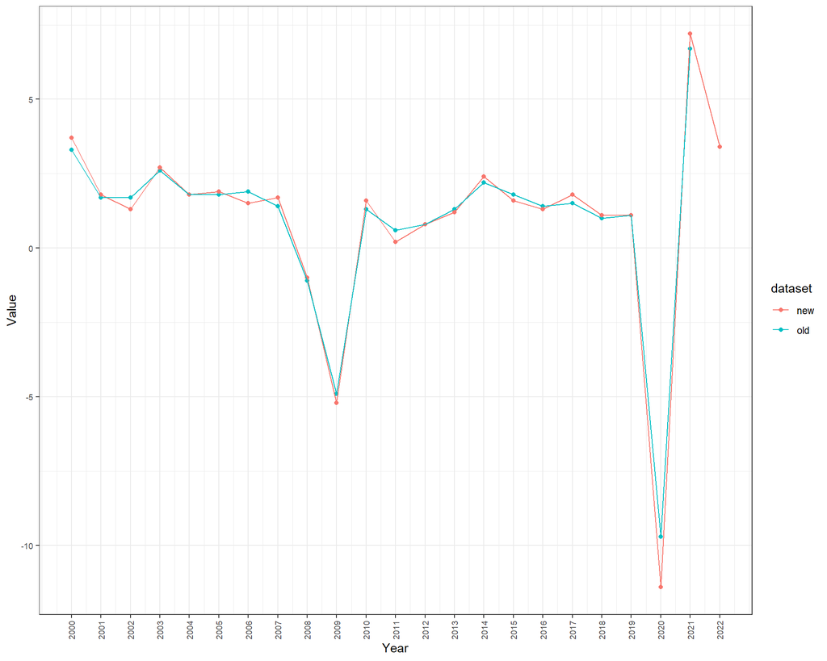

### Calculations

No calculations were performed on this data.